# MovieLens Project Questions_0916_1530

### 8. Visualize how popularity of genres has changed over the years - 10 marks

Note that you need to use the **percent of number of releases in a year** as a parameter of popularity of a genre

Hint 1: You need to reach to a data frame where the release year is the index and the genre is the column names (one cell shows the number of release in a year in one genre) or vice versa. (Drop unnecessary column if there are any)

Hint 2: Find the total number of movies release in a year(use `sum(axis=1)` store that value in a new column as 'total'). Now divide the value of each genre in that year by total to get percentage number of release in a particular year. `(df.div(df['total'], axis= 0) * 100)`

Once that is achieved, you can either use univariate plots or can use the heatmap to visualise all the changes over the years in one go.

Hint 3: Use groupby on the relevant column and use sum() on the same to find out the number of releases in a year/genre.

[figure not shown]

```python
df2= df_movieData.groupby('ReleaseYear')['movie title','Action','Adventure','Animation','Childrens','Comedy','Crime','Documentary','Drama','Fantasy'
          ,'Film-Noir','Horror','Musical','Mystery','Romance','Sci-Fi','Thriller','War','Western'].sum()

#df2 =pd.DataFrame(df_movieData.groupby('ReleaseYear')['Action','Adventure']).values()

df3= df_movieData.groupby('ReleaseYear')['movie title','Action','Adventure','Animation','Childrens','Comedy','Crime','Documentary','Drama','Fantasy'
          ,'Film-Noir','Horror','Musical','Mystery','Romance','Sci-Fi','Thriller','War','Western'].sum().sum(axis=1)
df2['GenreTotal'] =df3

df2
plt.figure(figsize=(240,200))
ax = (df2.div(df2['GenreTotal'], axis= 0) * 100).plot.bar()
plt.ylabel("Count [Passengers]", labelpad=16)
plt.xlabel("Date [Month - Year]", labelpad=16);
plt.show()
```

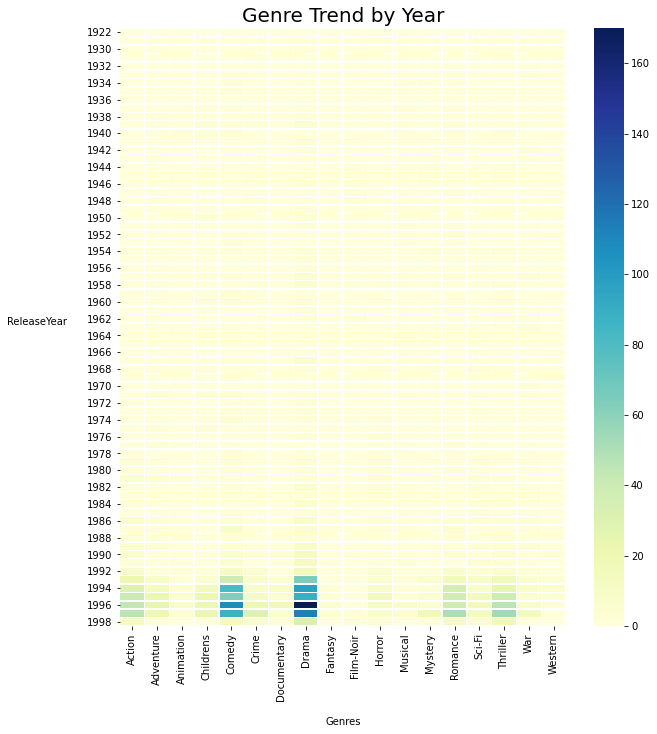

```python
df4 = df_movieData.groupby('ReleaseYear')['movie title','Action','Adventure','Animation','Childrens','Comedy','Crime','Documentary','Drama','Fantasy'
          ,'Film-Noir','Horror','Musical','Mystery','Romance','Sci-Fi','Thriller','War','Western'].sum()
figure, axes = plt.subplots(figsize=(10, 11))
#(df4.div(df2['GenreTotal'], axis= 0) * 100)
sns.heatmap(df4, annot=False,  linewidths=.5, ax=axes, cmap="YlGnBu")
axes.axes.set_title("Genre Trend by Year", fontsize=20, y=1.01)
axes.axes.set_ylabel("ReleaseYear", labelpad=50, rotation=0)
axes.axes.set_xlabel("Genres", labelpad=16);
plt.yticks(rotation=0);
```

```python
df4
```

| ReleaseYear | Action | Adventure | Animation | Childrens | Comedy | Crime | Documentary | Drama | Fantasy | Film-Noir | Horror | Musical | Mystery | Romance | Sci-Fi | Thriller | War | Western |
| --- | --- | --- | --- | --- | --- | --- | --- | --- | --- | --- | --- | --- | --- | --- | --- | --- | --- | --- |
| 1922 | 0 | 0 | 0 | 0 | 0 | 0 | 0 | 0 | 0 | 0 | 1 | 0 | 0 | 0 | 0 | 0 | 0 | 0 |
| 1926 | 0 | 0 | 0 | 0 | 0 | 0 | 0 | 1 | 0 | 0 | 0 | 0 | 0 | 0 | 0 | 0 | 0 | 0 |
| 1930 | 0 | 0 | 0 | 0 | 0 | 0 | 0 | 1 | 0 | 0 | 0 | 0 | 0 | 0 | 0 | 0 | 0 | 0 |
| 1931 | 0 | 0 | 0 | 0 | 0 | 1 | 0 | 0 | 0 | 1 | 0 | 0 | 0 | 0 | 0 | 1 | 0 | 0 |
| 1932 | 0 | 0 | 0 | 0 | 0 | 0 | 0 | 0 | 0 | 0 | 0 | 0 | 0 | 1 | 0 | 0 | 1 | 0 |
| ... | ... | ... | ... | ... | ... | ... | ... | ... | ... | ... | ... | ... | ... | ... | ... | ... | ... | ... |
| 1994 | 30 | 13 | 4 | 15 | 82 | 8 | 9 | 97 | 3 | 0 | 8 | 2 | 2 | 35 | 7 | 25 | 7 | 6 |
| 1995 | 40 | 22 | 6 | 21 | 63 | 11 | 5 | 89 | 3 | 1 | 14 | 3 | 5 | 37 | 15 | 39 | 5 | 2 |
| 1996 | 44 | 24 | 9 | 21 | 108 | 21 | 18 | 170 | 6 | 1 | 11 | 9 | 6 | 38 | 15 | 47 | 9 | 2 |
| 1997 | 46 | 20 | 3 | 22 | 87 | 30 | 6 | 113 | 4 | 2 | 8 | 5 | 18 | 51 | 13 | 54 | 14 | 0 |
| 1998 | 12 | 3 | 0 | 1 | 13 | 7 | 3 | 33 | 1 | 2 | 4 | 1 | 3 | 11 | 5 | 18 | 0 | 0 |

71 rows × 18 columns

```python
df2
```

| ReleaseYear | Action | Adventure | Animation | Childrens | Comedy | Crime | Documentary | Drama | Fantasy | Film-Noir | Horror | Musical | Mystery | Romance | Sci-Fi | Thriller | War | Western | GenreTotal |
| --- | --- | --- | --- | --- | --- | --- | --- | --- | --- | --- | --- | --- | --- | --- | --- | --- | --- | --- | --- |
| 1922 | 0 | 0 | 0 | 0 | 0 | 0 | 0 | 0 | 0 | 0 | 1 | 0 | 0 | 0 | 0 | 0 | 0 | 0 | 1 |
| 1926 | 0 | 0 | 0 | 0 | 0 | 0 | 0 | 1 | 0 | 0 | 0 | 0 | 0 | 0 | 0 | 0 | 0 | 0 | 1 |
| 1930 | 0 | 0 | 0 | 0 | 0 | 0 | 0 | 1 | 0 | 0 | 0 | 0 | 0 | 0 | 0 | 0 | 0 | 0 | 1 |
| 1931 | 0 | 0 | 0 | 0 | 0 | 1 | 0 | 0 | 0 | 1 | 0 | 0 | 0 | 0 | 0 | 1 | 0 | 0 | 3 |
| 1932 | 0 | 0 | 0 | 0 | 0 | 0 | 0 | 0 | 0 | 0 | 0 | 0 | 0 | 1 | 0 | 0 | 1 | 0 | 2 |
| ... | ... | ... | ... | ... | ... | ... | ... | ... | ... | ... | ... | ... | ... | ... | ... | ... | ... | ... | ... |
| 1994 | 30 | 13 | 4 | 15 | 82 | 8 | 9 | 97 | 3 | 0 | 8 | 2 | 2 | 35 | 7 | 25 | 7 | 6 | 353 |
| 1995 | 40 | 22 | 6 | 21 | 63 | 11 | 5 | 89 | 3 | 1 | 14 | 3 | 5 | 37 | 15 | 39 | 5 | 2 | 381 |
| 1996 | 44 | 24 | 9 | 21 | 108 | 21 | 18 | 170 | 6 | 1 | 11 | 9 | 6 | 38 | 15 | 47 | 9 | 2 | 559 |
| 1997 | 46 | 20 | 3 | 22 | 87 | 30 | 6 | 113 | 4 | 2 | 8 | 5 | 18 | 51 | 13 | 54 | 14 | 0 | 496 |
| 1998 | 12 | 3 | 0 | 1 | 13 | 7 | 3 | 33 | 1 | 2 | 4 | 1 | 3 | 11 | 5 | 18 | 0 | 0 | 117 |

71 rows × 19 columns

Hints :

1. Find the count of ratings and average ratings for every movie.
2. Slice the movies which have ratings more than 100.
3. Sort values according to average rating such that movie which highest rating is on top.
4. Select top 25 movies.
5. You will have to use the .merge() function to get the movie titles.

Note: This question will need you to research about groupby and apply your findings. You can find more on groupby on https://realpython.com/pandas-groupby/.

```python
dfUserRatedMovies =  pd.merge(df_movieData,df_userRatings)
dfUserRatedMovies.groupby('movie title')['rating'].count() # count of ratings
```

```
movie title
'Til There Was You                   9
1-900                                5
101 Dalmatians                     109
12 Angry Men                       125
187                                 41
                                  ...
Young Guns                         101
Young Guns II                       44
Young Poisoner's Handbook, The      41
Zeus and Roxanne                     6
Á köldum klaka (Cold Fever)          1
Name: rating, Length: 1658, dtype: int64
```

```python
dfUserRatedMovies.groupby('movie title')['rating'].mean() #average ratings for every movie.
```

```
movie title
'Til There Was You                 2.333333
1-900                              2.600000
101 Dalmatians                     2.908257
12 Angry Men                       4.344000
187                                3.024390
                                     ...
Young Guns                         3.207921
Young Guns II                      2.772727
Young Poisoner's Handbook, The     3.341463
Zeus and Roxanne                   2.166667
Á köldum klaka (Cold Fever)        3.000000
Name: rating, Length: 1658, dtype: float64
```

```python
dfGt100 =pd.DataFrame(dfUserRatedMovies.groupby('movie title')['rating'].sum())
dfGt100[dfGt100['rating'] >100]#Slice the movies which have ratings more than 100.
```

| movie title | rating |
| --- | --- |
| 101 Dalmatians | 317 |
| 12 Angry Men | 543 |
| 187 | 124 |
| 2 Days in the Valley | 300 |
| 20,000 Leagues Under the Sea | 252 |
| ... | ... |
| Wyatt Earp | 155 |
| Young Frankenstein | 789 |
| Young Guns | 324 |
| Young Guns II | 122 |
| Young Poisoner's Handbook, The | 137 |

764 rows × 1 columns

```python
dfUserRatedMovies.groupby('movie title')['rating'].mean().sort_values(ascending=False) #Sort values according to average rating such that movie which highest rating is on top.
```

```
movie title
Someone Else's America                    5.0
Marlene Dietrich: Shadow and Light (      5.0
Great Day in Harlem, A                    5.0
Santa with Muscles                        5.0
Saint of Fort Washington, The             5.0
                                         ...
Eye of Vichy, The (Oeil de Vichy, L')     1.0
Every Other Weekend                       1.0
Mille bolle blu                           1.0
The Courtyard                             1.0
Mighty, The                               1.0
Name: rating, Length: 1658, dtype: float64
```

```python
dfUserRatedMovies.groupby('movie title')['rating'].mean().sort_values(ascending=False).head(25) #Select top 25 movies.
```

```
movie title
Someone Else's America                              5.000000
Marlene Dietrich: Shadow and Light (                5.000000
Great Day in Harlem, A                              5.000000
Santa with Muscles                                  5.000000
Saint of Fort Washington, The                       5.000000
Aiqing wansui                                       5.000000
Prefontaine                                         5.000000
They Made Me a Criminal                             5.000000
Entertaining Angels: The Dorothy Day Story          5.000000
Star Kid                                            5.000000
Pather Panchali                                     4.625000
Anna                                                4.500000
Some Mother's Son                                   4.500000
Everest                                             4.500000
Maya Lin: A Strong Clear Vision                     4.500000
Close Shave, A                                      4.491071
Schindler's List                                    4.466443
Wrong Trousers, The                                 4.466102
Casablanca                                          4.456790
Wallace & Gromit: The Best of Aardman Animation     4.447761
Shawshank Redemption, The                           4.445230
Rear Window                                         4.387560
Usual Suspects, The                                 4.385768
Star Wars                                           4.358491
12 Angry Men                                        4.344000
Name: rating, dtype: float64
```

### 10. See gender distribution across different genres check for the validity of the below statements - 10 marks

- Men watch more drama than women
- Women watch more Sci-Fi than men
- Men watch more Romance than women

**compare the percentages**

1. Merge all the datasets
2. There is no need to conduct statistical tests around this. Just **compare the percentages** and comment on the validity of the above statements.
3. you might want ot use the .sum(), .div() function here.
4. Use number of ratings to validate the numbers. For example, if out of 4000 ratings received by women, 3000 are for drama, we will assume that 75% of the women watch drama.

```python
dfUserDataMovies = pd.merge(dfUserRatedMovies,df_userData) #Merge all the datasets

dfUserDataMovies.groupby('gender')['Drama'].sum()
dfsumAxis = dfUserDataMovies.groupby('gender')['Drama'].sum().sum(axis=0)
dfUserDataMovies.groupby('gender')['Drama'].sum()/dfsumAxis*100
#Men watch more drama than women is true
```

```
gender
F    27.59243
M    72.40757
Name: Drama, dtype: float64
```

```python
dfUserDataMovies = pd.merge(dfUserRatedMovies,df_userData) #Merge all the datasets

dfUserDataMovies.groupby('gender')['Sci-Fi'].sum()
dfsumAxis = dfUserDataMovies.groupby('gender')['Sci-Fi'].sum().sum(axis=0)
dfUserDataMovies.groupby('gender')['Sci-Fi'].sum()/dfsumAxis*100
#Women watch more Sci-Fi than men is False
```

```
gender
F    20.652003
M    79.347997
Name: Sci-Fi, dtype: float64
```

```python
dfUserDataMovies = pd.merge(dfUserRatedMovies,df_userData) #Merge all the datasets

dfUserDataMovies.groupby('gender')['Romance'].sum()
dfsumAxis = dfUserDataMovies.groupby('gender')['Romance'].sum().sum(axis=0)
dfUserDataMovies.groupby('gender')['Romance'].sum()/dfsumAxis*100
#Men watch more Romance than women is True
```

```
gender
F    30.101228
M    69.898772
Name: Romance, dtype: float64
```